# Praca domowa 2

## Zadanie 2

Wybierając klientów, którzy mają nieznany sposób kontaktu (`contact`). Jak rozkłada się ich wiek w podziale na status związku?

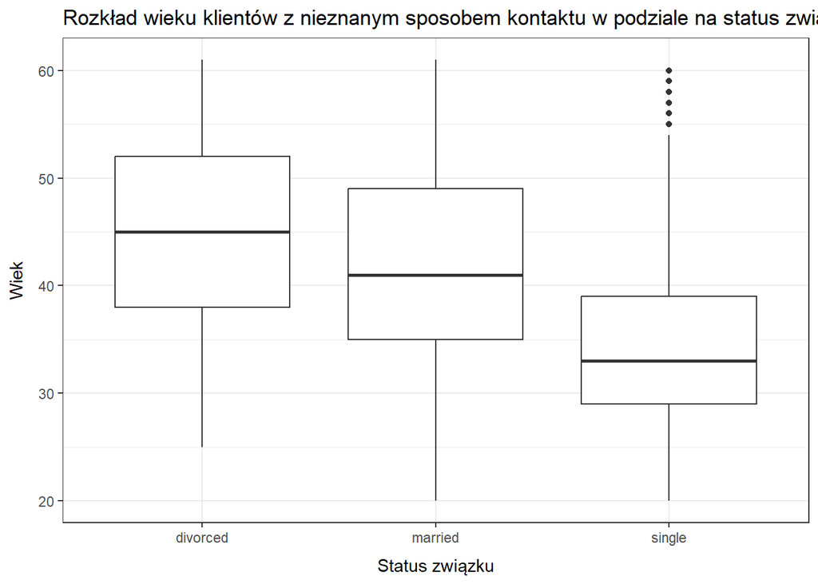

```r
# Ramki danych
zadanie2.1 <- df %>% filter(contact == "unknown") %>% group_by(marital)
zadanie2.2 <- df %>% filter(contact == "unknown") %>% group_by(age, marital) %>%
  summarise(licznosc = n()) %>% arrange(age, -licznosc)

#Wykresy
ggplot(zadanie2.1, aes(x = marital, y = age)) + geom_boxplot() +
  labs(title = "Rozkład wieku klientów z nieznanym sposobem kontaktu w podziale na status związku",
       x = "Status związku",
       y = "Wiek") + theme_bw() +
  theme(plot.title = element_text(size = 13)) +
  theme(axis.title.y = element_text(margin = margin(r = 8)),
        axis.title.x = element_text(margin = margin(t = 8)))
```

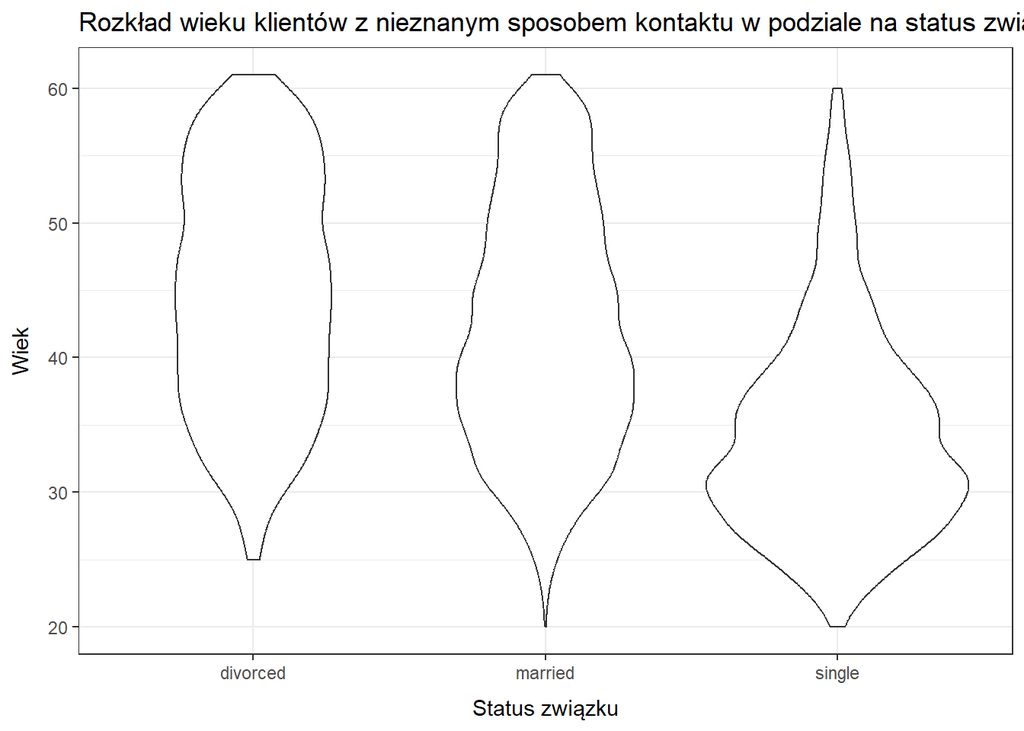

```r
ggplot(zadanie2.1, aes(x = marital, y = age)) + geom_violin() +
  labs(title = "Rozkład wieku klientów z nieznanym sposobem kontaktu w podziale na status związku",
       x = "Status związku",
       y = "Wiek") + theme_bw() +
  theme(plot.title = element_text(size = 13)) +
  theme(axis.title.y = element_text(margin = margin(r = 8)),
        axis.title.x = element_text(margin = margin(t = 8)))
```

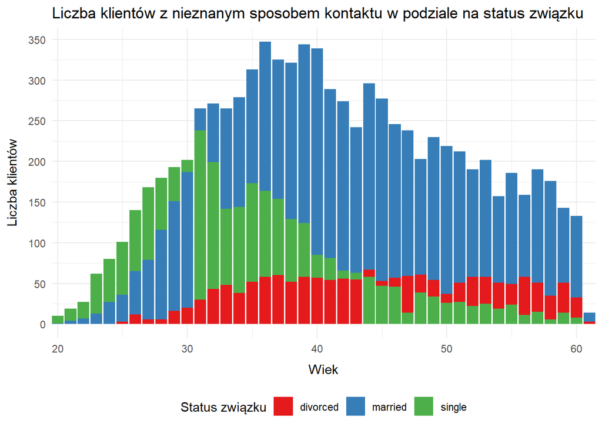

```r
ggplot(zadanie2.2, aes(x = age, y = licznosc, fill = marital)) +
  geom_col(position = "identity") +
  labs(title = "Liczba klientów z nieznanym sposobem kontaktu w podziale na status związku",
       x = "Wiek",
       y = "Liczba klientów",
       fill = "Status związku") + theme_minimal() +
  scale_fill_brewer(palette = "Set1") +
  theme(legend.position = "bottom") +
  theme(plot.title = element_text(size = 13)) +
  theme(axis.title.y = element_text(margin = margin(r = 8)),
        axis.title.x = element_text(margin = margin(t = 8))) +
  scale_x_continuous(expand = c(0, 0)) +
  scale_y_continuous(expand = c(0,0)) + ylim(c(0, 400)) +
  scale_y_continuous(breaks = seq(0, 400, by = 50))
```

```r
# Dane do opisu:
min(zadanie2.1$age)
```

```
## [1] 20
```

```r
max(zadanie2.1$age)
```

```
## [1] 61
```

```r
zadanie2.2 %>% group_by(age, marital) %>% summarise(licznosc = sum(licznosc)) %>%
  filter(licznosc == max(licznosc)) %>% filter(marital == "married") %>% head(1)
```

```
## # A tibble: 1 × 3
## # Groups:   age [1]
##     age marital licznosc
##   <int> <chr>      <int>
## 1    31 married      265
```

```r
zadanie2.2 %>% group_by(age, marital) %>% summarise(licznosc = sum(licznosc)) %>%
  filter(licznosc == max(licznosc)) %>% filter(marital == "single") %>% arrange(-licznosc) %>% head(1)
```

```
## # A tibble: 1 × 3
## # Groups:   age [1]
##     age marital licznosc
##   <int> <chr>      <int>
## 1    30 single       202
```

```r
zadanie2.2 %>% group_by(age, marital) %>% summarise(licznosc = sum(licznosc)) %>%
  filter(licznosc == max(licznosc)) %>% filter(marital == "married") %>% arrange(licznosc) %>% head(1)
```

```
## # A tibble: 1 × 3
## # Groups:   age [1]
##     age marital licznosc
##   <int> <chr>      <int>
## 1    61 married       14
```

```r
zadanie2.2 %>% group_by(age, marital) %>% summarise(licznosc = sum(licznosc)) %>%
  filter(licznosc == max(licznosc)) %>% filter(marital == "divorced") %>% arrange(desc(licznosc)) %>% head(1)
```

```
## # A tibble: 0 × 3
## # Groups:   age [0]
## # ℹ 3 variables: age <int>, marital <chr>, licznosc <int>
```

```r
max(zadanie2.2$licznosc)
```

```
## [1] 347
```

```r
zadanie2.2$age[zadanie2.2$licznosc == max(zadanie2.2$licznosc)]
```

```
## [1] 36
```

```r
zadanie2.2$marital[zadanie2.2$licznosc == max(zadanie2.2$licznosc)]
```

```
## [1] "married"
```

```r
zadanie2.2$age[zadanie2.2$licznosc == max(zadanie2.2$licznosc)]
```

```
## [1] 36
```

```r
zadanie2.2 %>% filter(marital == "married") %>% arrange(age) %>% head(1)
```

```
## # A tibble: 1 × 3
## # Groups:   age [1]
##     age marital licznosc
##   <int> <chr>      <int>
## 1    20 married        1
```

```r
zadanie2.2 %>% filter(marital == "single") %>% arrange(age) %>% head(1)
```

```
## # A tibble: 1 × 3
## # Groups:   age [1]
##     age marital licznosc
##   <int> <chr>      <int>
## 1    20 single        10
```

```r
zadanie2.2 %>% filter(marital == "divorced") %>% arrange(age) %>% head(1)
```

```
## # A tibble: 1 × 3
## # Groups:   age [1]
##     age marital  licznosc
##   <int> <chr>       <int>
## 1    25 divorced        3
```

```r
zadanie2.2 %>% filter(marital == "married") %>% arrange(-age) %>% head(1)
```

```
## # A tibble: 1 × 3
## # Groups:   age [1]
##     age marital licznosc
##   <int> <chr>      <int>
## 1    61 married       14
```

```r
zadanie2.2 %>% filter(marital == "single") %>% arrange(-age) %>% head(1)
```

```
## # A tibble: 1 × 3
## # Groups:   age [1]
##     age marital licznosc
##   <int> <chr>      <int>
## 1    60 single         8
```

```r
zadanie2.2 %>% filter(marital == "divorced") %>% arrange(-age) %>% head(1)
```

```
## # A tibble: 1 × 3
## # Groups:   age [1]
##     age marital  licznosc
##   <int> <chr>       <int>
## 1    61 divorced        3
```

```r
zadanie2.2 %>% filter(marital == "single" | marital == "divorced") %>% group_by(age, marital) %>% summarise(licznosc = sum(licznosc)) %>%
  filter(licznosc == max(licznosc)) %>% filter(marital == "divorced") %>% head(1)
```

```
## # A tibble: 1 × 3
## # Groups:   age [1]
##     age marital  licznosc
##   <int> <chr>       <int>
## 1    44 divorced       67
```

```r
zadanie2.2 %>% filter(marital == "single") %>% arrange(-licznosc)%>% head(1)
```

```
## # A tibble: 1 × 3
## # Groups:   age [1]
##     age marital licznosc
##   <int> <chr>      <int>
## 1    31 single       238
```

```r
zadanie2.2 %>% filter(marital == "married") %>% arrange(-licznosc)%>% head(1)
```

```
## # A tibble: 1 × 3
## # Groups:   age [1]
##     age marital licznosc
##   <int> <chr>      <int>
## 1    36 married      347
```

```r
zadanie2.2 %>% filter(marital == "divorced") %>% arrange(-licznosc) %>% head(1)
```

```
## # A tibble: 1 × 3
## # Groups:   age [1]
##     age marital  licznosc
##   <int> <chr>       <int>
## 1    44 divorced       67
```

**Komentarz:** Dla klientów, którzy mają niemnany sposób kontaktu, najmłodszy ma 20 lat, a najstarszy 61 lat. W przedziale wiekowym od najmłodszego klienta, do 30 lat najwięcej klientów ma status single (na drugiej pozycji znajduje się married), od 31 lat do ostatniej osoby w zestawieniu dominuje status married, na drugiej pozycji do 43 lat jest single, a następnie aż do końca zestawienia jest to divorced. Największą grupę stanowyły osoby w wieku 36 lat w grupie married, było ich 347. Dla statusu married, najmłodsza osoba jest w wieku 20 lat, a najstarsza w wieku 61 lat, dla single jest to 20 i 60 lat, natomiast dla divorced 25 i 61 lat. W poszczególnych kategoriach widzimy tendencję wzrostu do pewnego wieku, a następnie spadek, jedynie w kategorii married jest pewne wypłaszczenie zanim zacznie spadać, modę married osiąga dla wieku 36 lat, single dla 31, natomiast divorced dla 44. Widzimy również, że dla statusu single występują obserwacje odstające, są one mniej więcej dla wiku od 55 lat, mediana występuje dla wieku około 33 lat, widzimy również, że 75% klientów z tej kategorii kontaktowało się przed połową mającą status married oraz dovorced, w których mediany przypadają na wiek odpowiednio około 41 lat i 45 lat.